# Risk Factor Analysis

## Outcome Variable

**Outcome Variable:** ever_stunted

## Predictor Variables

**Intervention Variable:** impsan

**Adjustment Set:**

- arm
- sex
- W_mage
- meducyrs
- feducyrs
- hhwealth_quart
- hfoodsec
- W_mhtcm
- W_mwtkg
- W_mbmi
- W_nrooms
- W_nchldlt5
- W_parity
- impfloor
- safeh20
- delta_W_mage
- delta_meducyrs
- delta_feducyrs
- delta_hhwealth_quart
- delta_hfoodsec
- delta_W_mhtcm
- delta_W_mwtkg
- delta_W_mbmi
- delta_W_nrooms
- delta_W_nchldlt5
- delta_W_parity
- delta_impfloor
- delta_safeh20

## Stratifying Variables

The analysis was stratified on these variable(s):

- agecat
- studyid
- country

## Data Summary

| agecat | studyid | country | impsan | ever_stunted | n_cell | n |
| --- | --- | --- | --- | --- | --- | --- |
| 0-24 months (no birth st.) | COHORTS | GUATEMALA | 1 | 0 | 16 | 635 |
| 0-24 months (no birth st.) | COHORTS | GUATEMALA | 1 | 1 | 49 | 635 |
| 0-24 months (no birth st.) | COHORTS | GUATEMALA | 0 | 0 | 104 | 635 |
| 0-24 months (no birth st.) | COHORTS | GUATEMALA | 0 | 1 | 466 | 635 |
| 0-24 months (no birth st.) | COHORTS | INDIA | 1 | 0 | 1423 | 4715 |
| 0-24 months (no birth st.) | COHORTS | INDIA | 1 | 1 | 389 | 4715 |
| 0-24 months (no birth st.) | COHORTS | INDIA | 0 | 0 | 1871 | 4715 |
| 0-24 months (no birth st.) | COHORTS | INDIA | 0 | 1 | 1032 | 4715 |
| 0-24 months (no birth st.) | COHORTS | PHILIPPINES | 1 | 0 | 102 | 1115 |
| 0-24 months (no birth st.) | COHORTS | PHILIPPINES | 1 | 1 | 75 | 1115 |
| 0-24 months (no birth st.) | COHORTS | PHILIPPINES | 0 | 0 | 207 | 1115 |
| 0-24 months (no birth st.) | COHORTS | PHILIPPINES | 0 | 1 | 731 | 1115 |
| 0-24 months (no birth st.) | CONTENT | PERU | 1 | 0 | 154 | 195 |
| 0-24 months (no birth st.) | CONTENT | PERU | 1 | 1 | 29 | 195 |
| 0-24 months (no birth st.) | CONTENT | PERU | 0 | 0 | 8 | 195 |
| 0-24 months (no birth st.) | CONTENT | PERU | 0 | 1 | 4 | 195 |
| 0-24 months (no birth st.) | JiVitA-3 | BANGLADESH | 1 | 0 | 10052 | 18353 |
| 0-24 months (no birth st.) | JiVitA-3 | BANGLADESH | 1 | 1 | 3074 | 18353 |
| 0-24 months (no birth st.) | JiVitA-3 | BANGLADESH | 0 | 0 | 3669 | 18353 |
| 0-24 months (no birth st.) | JiVitA-3 | BANGLADESH | 0 | 1 | 1558 | 18353 |
| 0-24 months (no birth st.) | JiVitA-4 | BANGLADESH | 1 | 0 | 1830 | 3875 |
| 0-24 months (no birth st.) | JiVitA-4 | BANGLADESH | 1 | 1 | 1217 | 3875 |
| 0-24 months (no birth st.) | JiVitA-4 | BANGLADESH | 0 | 0 | 439 | 3875 |
| 0-24 months (no birth st.) | JiVitA-4 | BANGLADESH | 0 | 1 | 389 | 3875 |
| 0-24 months (no birth st.) | LCNI-5 | MALAWI | 1 | 0 | 2 | 518 |
| 0-24 months (no birth st.) | LCNI-5 | MALAWI | 1 | 1 | 0 | 518 |
| 0-24 months (no birth st.) | LCNI-5 | MALAWI | 0 | 0 | 293 | 518 |
| 0-24 months (no birth st.) | LCNI-5 | MALAWI | 0 | 1 | 223 | 518 |
| 0-24 months (no birth st.) | MAL-ED | BANGLADESH | 1 | 0 | 82 | 203 |
| 0-24 months (no birth st.) | MAL-ED | BANGLADESH | 1 | 1 | 88 | 203 |

[output cut: 106 more lines]

The following strata were considered:

- agecat: 0-24 months (no birth st.), studyid: COHORTS, country: GUATEMALA
- agecat: 0-24 months (no birth st.), studyid: COHORTS, country: INDIA
- agecat: 0-24 months (no birth st.), studyid: COHORTS, country: PHILIPPINES
- agecat: 0-24 months (no birth st.), studyid: CONTENT, country: PERU
- agecat: 0-24 months (no birth st.), studyid: JiVitA-3, country: BANGLADESH
- agecat: 0-24 months (no birth st.), studyid: JiVitA-4, country: BANGLADESH
- agecat: 0-24 months (no birth st.), studyid: LCNI-5, country: MALAWI
- agecat: 0-24 months (no birth st.), studyid: MAL-ED, country: BANGLADESH
- agecat: 0-24 months (no birth st.), studyid: MAL-ED, country: BRAZIL
- agecat: 0-24 months (no birth st.), studyid: MAL-ED, country: INDIA
- agecat: 0-24 months (no birth st.), studyid: MAL-ED, country: NEPAL
- agecat: 0-24 months (no birth st.), studyid: MAL-ED, country: PERU
- agecat: 0-24 months (no birth st.), studyid: MAL-ED, country: SOUTH AFRICA
- agecat: 0-24 months (no birth st.), studyid: MAL-ED, country: TANZANIA, UNITED REPUBLIC OF
- agecat: 0-24 months (no birth st.), studyid: NIH-Birth, country: BANGLADESH
- agecat: 0-24 months (no birth st.), studyid: NIH-Crypto, country: BANGLADESH
- agecat: 0-24 months (no birth st.), studyid: PROVIDE, country: BANGLADESH
- agecat: 0-6 months (no birth st.), studyid: COHORTS, country: GUATEMALA
- agecat: 0-6 months (no birth st.), studyid: COHORTS, country: INDIA
- agecat: 0-6 months (no birth st.), studyid: COHORTS, country: PHILIPPINES
- agecat: 0-6 months (no birth st.), studyid: CONTENT, country: PERU
- agecat: 0-6 months (no birth st.), studyid: JiVitA-3, country: BANGLADESH
- agecat: 0-6 months (no birth st.), studyid: JiVitA-4, country: BANGLADESH
- agecat: 0-6 months (no birth st.), studyid: LCNI-5, country: MALAWI
- agecat: 0-6 months (no birth st.), studyid: MAL-ED, country: BANGLADESH
- agecat: 0-6 months (no birth st.), studyid: MAL-ED, country: BRAZIL
- agecat: 0-6 months (no birth st.), studyid: MAL-ED, country: INDIA
- agecat: 0-6 months (no birth st.), studyid: MAL-ED, country: NEPAL
- agecat: 0-6 months (no birth st.), studyid: MAL-ED, country: PERU
- agecat: 0-6 months (no birth st.), studyid: MAL-ED, country: SOUTH AFRICA
- agecat: 0-6 months (no birth st.), studyid: MAL-ED, country: TANZANIA, UNITED REPUBLIC OF
- agecat: 0-6 months (no birth st.), studyid: NIH-Birth, country: BANGLADESH
- agecat: 0-6 months (no birth st.), studyid: NIH-Crypto, country: BANGLADESH
- agecat: 0-6 months (no birth st.), studyid: PROVIDE, country: BANGLADESH

### Dropped Strata

Some strata were dropped due to rare outcomes:

- agecat: 0-24 months (no birth st.), studyid: CONTENT, country: PERU
- agecat: 0-24 months (no birth st.), studyid: LCNI-5, country: MALAWI
- agecat: 0-24 months (no birth st.), studyid: MAL-ED, country: BRAZIL
- agecat: 0-24 months (no birth st.), studyid: MAL-ED, country: NEPAL
- agecat: 0-24 months (no birth st.), studyid: MAL-ED, country: SOUTH AFRICA
- agecat: 0-24 months (no birth st.), studyid: MAL-ED, country: TANZANIA, UNITED REPUBLIC OF
- agecat: 0-24 months (no birth st.), studyid: PROVIDE, country: BANGLADESH
- agecat: 0-6 months (no birth st.), studyid: CONTENT, country: PERU
- agecat: 0-6 months (no birth st.), studyid: LCNI-5, country: MALAWI
- agecat: 0-6 months (no birth st.), studyid: MAL-ED, country: BRAZIL
- agecat: 0-6 months (no birth st.), studyid: MAL-ED, country: NEPAL
- agecat: 0-6 months (no birth st.), studyid: MAL-ED, country: SOUTH AFRICA
- agecat: 0-6 months (no birth st.), studyid: MAL-ED, country: TANZANIA, UNITED REPUBLIC OF
- agecat: 0-6 months (no birth st.), studyid: PROVIDE, country: BANGLADESH

## Methods Detail

We're interested in the causal parameters $E[Y_a]$ for all values of $a \in \mathcal{A}$. These parameters represent the mean outcome if, possibly contrary to fact, we intervened to set all units to have $A=a$. Under the randomization and positivity assumptions, these are identified by the statistical parameters $\psi_a=E_W[E_{Y|A,W}(Y|A=a,W)]$. In addition, we're interested in the mean of $Y$, $E[Y]$ under no intervention (the observed mean). We will estimate these parameters by using SuperLearner to fit the relevant likelihood factors -- $E_{Y|A,W}(Y|A=a,W)$ and $p(A=a|W)$, and then updating our likelihood fit using a joint TMLE.

For unadjusted analyses ($W=\{\}$), initial likelihoods were estimated using Lrnr_glm to estimate the simple $E(Y|A)$ and Lrnr_mean to estimate $p(A)$. For adjusted analyses, a small library containing Lrnr_glmnet, Lrnr_xgboost, and Lrnr_mean was used.

Having estimated these parameters, we will then use the delta method to estimate relative risks and attributable risks relative to a prespecified baseline level of $A$.

# Results Detail

## Results Plots

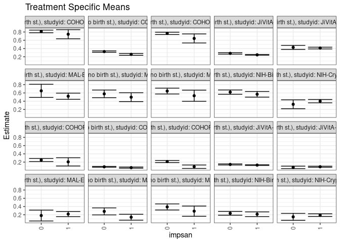

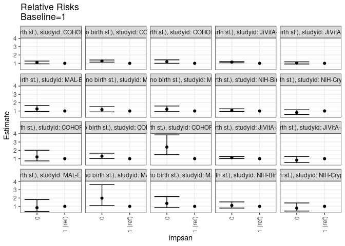

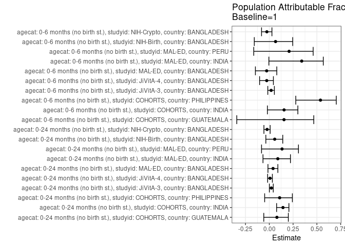

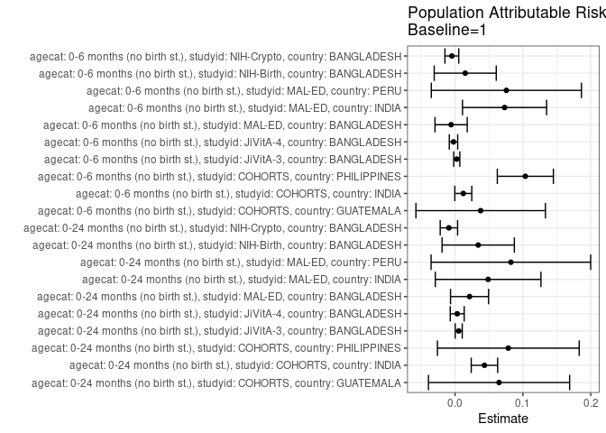

## Results Table

### Parameter: TSM

| agecat | studyid | country | intervention_level | baseline_level | estimate | ci_lower | ci_upper |
| --- | --- | --- | --- | --- | --- | --- | --- |
| 0-24 months (no birth st.) | COHORTS | GUATEMALA | 1 | NA | 0.7461641 | 0.6358549 | 0.8564732 |
| 0-24 months (no birth st.) | COHORTS | GUATEMALA | 0 | NA | 0.8139634 | 0.7820739 | 0.8458529 |
| 0-24 months (no birth st.) | COHORTS | INDIA | 1 | NA | 0.2580435 | 0.2352588 | 0.2808282 |
| 0-24 months (no birth st.) | COHORTS | INDIA | 0 | NA | 0.3258433 | 0.3086242 | 0.3430623 |
| 0-24 months (no birth st.) | COHORTS | PHILIPPINES | 1 | NA | 0.6443500 | 0.5349989 | 0.7537011 |
| 0-24 months (no birth st.) | COHORTS | PHILIPPINES | 0 | NA | 0.7671494 | 0.7388346 | 0.7954642 |
| 0-24 months (no birth st.) | JiVitA-3 | BANGLADESH | 1 | NA | 0.2469722 | 0.2375385 | 0.2564059 |
| 0-24 months (no birth st.) | JiVitA-3 | BANGLADESH | 0 | NA | 0.2824677 | 0.2643934 | 0.3005420 |
| 0-24 months (no birth st.) | JiVitA-4 | BANGLADESH | 1 | NA | 0.4112517 | 0.3903139 | 0.4321895 |
| 0-24 months (no birth st.) | JiVitA-4 | BANGLADESH | 0 | NA | 0.4272512 | 0.3784294 | 0.4760730 |
| 0-24 months (no birth st.) | MAL-ED | BANGLADESH | 1 | NA | 0.5205144 | 0.4455711 | 0.5954577 |
| 0-24 months (no birth st.) | MAL-ED | BANGLADESH | 0 | NA | 0.6509021 | 0.4916203 | 0.8101839 |
| 0-24 months (no birth st.) | MAL-ED | INDIA | 1 | NA | 0.4971430 | 0.3903572 | 0.6039288 |
| 0-24 months (no birth st.) | MAL-ED | INDIA | 0 | NA | 0.5774621 | 0.4847972 | 0.6701270 |
| 0-24 months (no birth st.) | MAL-ED | PERU | 1 | NA | 0.5324094 | 0.3972239 | 0.6675948 |
| 0-24 months (no birth st.) | MAL-ED | PERU | 0 | NA | 0.6454571 | 0.5746413 | 0.7162729 |
| 0-24 months (no birth st.) | NIH-Birth | BANGLADESH | 1 | NA | 0.5677671 | 0.4991957 | 0.6363385 |
| 0-24 months (no birth st.) | NIH-Birth | BANGLADESH | 0 | NA | 0.6195705 | 0.5673112 | 0.6718297 |
| 0-24 months (no birth st.) | NIH-Crypto | BANGLADESH | 1 | NA | 0.4009885 | 0.3608310 | 0.4411460 |
| 0-24 months (no birth st.) | NIH-Crypto | BANGLADESH | 0 | NA | 0.3250189 | 0.2178666 | 0.4321711 |
| 0-6 months (no birth st.) | COHORTS | GUATEMALA | 1 | NA | 0.2064631 | 0.1063986 | 0.3065276 |
| 0-6 months (no birth st.) | COHORTS | GUATEMALA | 0 | NA | 0.2507626 | 0.2129706 | 0.2885545 |
| 0-6 months (no birth st.) | COHORTS | INDIA | 1 | NA | 0.0661907 | 0.0521011 | 0.0802803 |
| 0-6 months (no birth st.) | COHORTS | INDIA | 0 | NA | 0.0863227 | 0.0760502 | 0.0965953 |
| 0-6 months (no birth st.) | COHORTS | PHILIPPINES | 1 | NA | 0.0891794 | 0.0478306 | 0.1305281 |
| 0-6 months (no birth st.) | COHORTS | PHILIPPINES | 0 | NA | 0.2132555 | 0.1870417 | 0.2394694 |
| 0-6 months (no birth st.) | JiVitA-3 | BANGLADESH | 1 | NA | 0.1278455 | 0.1205930 | 0.1350981 |
| 0-6 months (no birth st.) | JiVitA-3 | BANGLADESH | 0 | NA | 0.1439582 | 0.1306493 | 0.1572670 |
| 0-6 months (no birth st.) | JiVitA-4 | BANGLADESH | 1 | NA | 0.0877545 | 0.0745933 | 0.1009157 |
| 0-6 months (no birth st.) | JiVitA-4 | BANGLADESH | 0 | NA | 0.0722573 | 0.0421203 | 0.1023944 |
| 0-6 months (no birth st.) | MAL-ED | BANGLADESH | 1 | NA | 0.2176471 | 0.1554638 | 0.2798304 |
| 0-6 months (no birth st.) | MAL-ED | BANGLADESH | 0 | NA | 0.1818182 | 0.0498993 | 0.3137371 |
| 0-6 months (no birth st.) | MAL-ED | INDIA | 1 | NA | 0.1413087 | 0.0697102 | 0.2129073 |
| 0-6 months (no birth st.) | MAL-ED | INDIA | 0 | NA | 0.2823464 | 0.1972964 | 0.3673964 |
| 0-6 months (no birth st.) | MAL-ED | PERU | 1 | NA | 0.2879747 | 0.1640281 | 0.4119213 |
| 0-6 months (no birth st.) | MAL-ED | PERU | 0 | NA | 0.3902601 | 0.3168671 | 0.4636532 |
| 0-6 months (no birth st.) | NIH-Birth | BANGLADESH | 1 | NA | 0.2132936 | 0.1562117 | 0.2703755 |
| 0-6 months (no birth st.) | NIH-Birth | BANGLADESH | 0 | NA | 0.2359935 | 0.1901857 | 0.2818012 |
| 0-6 months (no birth st.) | NIH-Crypto | BANGLADESH | 1 | NA | 0.1913756 | 0.1590625 | 0.2236888 |
| 0-6 months (no birth st.) | NIH-Crypto | BANGLADESH | 0 | NA | 0.1501268 | 0.0660791 | 0.2341744 |

### Parameter: E(Y)

| agecat | studyid | country | intervention_level | baseline_level | estimate | ci_lower | ci_upper |
| --- | --- | --- | --- | --- | --- | --- | --- |
| 0-24 months (no birth st.) | COHORTS | GUATEMALA | NA | NA | 0.8110236 | 0.7805500 | 0.8414972 |
| 0-24 months (no birth st.) | COHORTS | INDIA | NA | NA | 0.3013786 | 0.2882798 | 0.3144773 |
| 0-24 months (no birth st.) | COHORTS | PHILIPPINES | NA | NA | 0.7228700 | 0.6965868 | 0.7491531 |
| 0-24 months (no birth st.) | JiVitA-3 | BANGLADESH | NA | NA | 0.2523838 | 0.2446469 | 0.2601207 |
| 0-24 months (no birth st.) | JiVitA-4 | BANGLADESH | NA | NA | 0.4144516 | 0.3962595 | 0.4326437 |
| 0-24 months (no birth st.) | MAL-ED | BANGLADESH | NA | NA | 0.5418719 | 0.4731628 | 0.6105810 |
| 0-24 months (no birth st.) | MAL-ED | INDIA | NA | NA | 0.5459184 | 0.4760370 | 0.6157998 |
| 0-24 months (no birth st.) | MAL-ED | PERU | NA | NA | 0.6147186 | 0.5518243 | 0.6776129 |
| 0-24 months (no birth st.) | NIH-Birth | BANGLADESH | NA | NA | 0.6018868 | 0.5601729 | 0.6436007 |
| 0-24 months (no birth st.) | NIH-Crypto | BANGLADESH | NA | NA | 0.3919129 | 0.3541506 | 0.4296752 |
| 0-6 months (no birth st.) | COHORTS | GUATEMALA | NA | NA | 0.2442478 | 0.2087898 | 0.2797057 |
| 0-6 months (no birth st.) | COHORTS | INDIA | NA | NA | 0.0783541 | 0.0705612 | 0.0861470 |
| 0-6 months (no birth st.) | COHORTS | PHILIPPINES | NA | NA | 0.1928251 | 0.1696580 | 0.2159922 |
| 0-6 months (no birth st.) | JiVitA-3 | BANGLADESH | NA | NA | 0.1303730 | 0.1247937 | 0.1359524 |
| 0-6 months (no birth st.) | JiVitA-4 | BANGLADESH | NA | NA | 0.0854560 | 0.0740923 | 0.0968198 |
| 0-6 months (no birth st.) | MAL-ED | BANGLADESH | NA | NA | 0.2118227 | 0.1554757 | 0.2681696 |
| 0-6 months (no birth st.) | MAL-ED | INDIA | NA | NA | 0.2142857 | 0.1566940 | 0.2718774 |
| 0-6 months (no birth st.) | MAL-ED | PERU | NA | NA | 0.3636364 | 0.3014678 | 0.4258049 |
| 0-6 months (no birth st.) | NIH-Birth | BANGLADESH | NA | NA | 0.2283019 | 0.1925336 | 0.2640702 |
| 0-6 months (no birth st.) | NIH-Crypto | BANGLADESH | NA | NA | 0.1866252 | 0.1564874 | 0.2167630 |

### Parameter: RR

| agecat | studyid | country | intervention_level | baseline_level | estimate | ci_lower | ci_upper |
| --- | --- | --- | --- | --- | --- | --- | --- |
| 0-24 months (no birth st.) | COHORTS | GUATEMALA | 1 | 1 | 1.0000000 | 1.0000000 | 1.000000 |
| 0-24 months (no birth st.) | COHORTS | GUATEMALA | 0 | 1 | 1.0908638 | 0.9367494 | 1.270333 |
| 0-24 months (no birth st.) | COHORTS | INDIA | 1 | 1 | 1.0000000 | 1.0000000 | 1.000000 |
| 0-24 months (no birth st.) | COHORTS | INDIA | 0 | 1 | 1.2627455 | 1.1407231 | 1.397820 |
| 0-24 months (no birth st.) | COHORTS | PHILIPPINES | 1 | 1 | 1.0000000 | 1.0000000 | 1.000000 |
| 0-24 months (no birth st.) | COHORTS | PHILIPPINES | 0 | 1 | 1.1905788 | 1.0014962 | 1.415360 |
| 0-24 months (no birth st.) | JiVitA-3 | BANGLADESH | 1 | 1 | 1.0000000 | 1.0000000 | 1.000000 |
| 0-24 months (no birth st.) | JiVitA-3 | BANGLADESH | 0 | 1 | 1.1437227 | 1.0661422 | 1.226948 |
| 0-24 months (no birth st.) | JiVitA-4 | BANGLADESH | 1 | 1 | 1.0000000 | 1.0000000 | 1.000000 |
| 0-24 months (no birth st.) | JiVitA-4 | BANGLADESH | 0 | 1 | 1.0389045 | 0.9172763 | 1.176660 |
| 0-24 months (no birth st.) | MAL-ED | BANGLADESH | 1 | 1 | 1.0000000 | 1.0000000 | 1.000000 |
| 0-24 months (no birth st.) | MAL-ED | BANGLADESH | 0 | 1 | 1.2504977 | 0.9468287 | 1.651560 |
| 0-24 months (no birth st.) | MAL-ED | INDIA | 1 | 1 | 1.0000000 | 1.0000000 | 1.000000 |
| 0-24 months (no birth st.) | MAL-ED | INDIA | 0 | 1 | 1.1615613 | 0.8901309 | 1.515760 |
| 0-24 months (no birth st.) | MAL-ED | PERU | 1 | 1 | 1.0000000 | 1.0000000 | 1.000000 |
| 0-24 months (no birth st.) | MAL-ED | PERU | 0 | 1 | 1.2123323 | 0.9183620 | 1.600403 |
| 0-24 months (no birth st.) | NIH-Birth | BANGLADESH | 1 | 1 | 1.0000000 | 1.0000000 | 1.000000 |
| 0-24 months (no birth st.) | NIH-Birth | BANGLADESH | 0 | 1 | 1.0912404 | 0.9439839 | 1.261468 |
| 0-24 months (no birth st.) | NIH-Crypto | BANGLADESH | 1 | 1 | 1.0000000 | 1.0000000 | 1.000000 |
| 0-24 months (no birth st.) | NIH-Crypto | BANGLADESH | 0 | 1 | 0.8105441 | 0.5754470 | 1.141689 |
| 0-6 months (no birth st.) | COHORTS | GUATEMALA | 1 | 1 | 1.0000000 | 1.0000000 | 1.000000 |
| 0-6 months (no birth st.) | COHORTS | GUATEMALA | 0 | 1 | 1.2145636 | 0.7317183 | 2.016028 |
| 0-6 months (no birth st.) | COHORTS | INDIA | 1 | 1 | 1.0000000 | 1.0000000 | 1.000000 |
| 0-6 months (no birth st.) | COHORTS | INDIA | 0 | 1 | 1.3041512 | 1.0226194 | 1.663190 |
| 0-6 months (no birth st.) | COHORTS | PHILIPPINES | 1 | 1 | 1.0000000 | 1.0000000 | 1.000000 |
| 0-6 months (no birth st.) | COHORTS | PHILIPPINES | 0 | 1 | 2.3913108 | 1.4803171 | 3.862934 |
| 0-6 months (no birth st.) | JiVitA-3 | BANGLADESH | 1 | 1 | 1.0000000 | 1.0000000 | 1.000000 |
| 0-6 months (no birth st.) | JiVitA-3 | BANGLADESH | 0 | 1 | 1.1260321 | 1.0147943 | 1.249463 |
| 0-6 months (no birth st.) | JiVitA-4 | BANGLADESH | 1 | 1 | 1.0000000 | 1.0000000 | 1.000000 |
| 0-6 months (no birth st.) | JiVitA-4 | BANGLADESH | 0 | 1 | 0.8234032 | 0.5326587 | 1.272847 |
| 0-6 months (no birth st.) | MAL-ED | BANGLADESH | 1 | 1 | 1.0000000 | 1.0000000 | 1.000000 |
| 0-6 months (no birth st.) | MAL-ED | BANGLADESH | 0 | 1 | 0.8353808 | 0.3830278 | 1.821959 |
| 0-6 months (no birth st.) | MAL-ED | INDIA | 1 | 1 | 1.0000000 | 1.0000000 | 1.000000 |
| 0-6 months (no birth st.) | MAL-ED | INDIA | 0 | 1 | 1.9980815 | 1.1050183 | 3.612908 |
| 0-6 months (no birth st.) | MAL-ED | PERU | 1 | 1 | 1.0000000 | 1.0000000 | 1.000000 |
| 0-6 months (no birth st.) | MAL-ED | PERU | 0 | 1 | 1.3551891 | 0.8466848 | 2.169092 |
| 0-6 months (no birth st.) | NIH-Birth | BANGLADESH | 1 | 1 | 1.0000000 | 1.0000000 | 1.000000 |
| 0-6 months (no birth st.) | NIH-Birth | BANGLADESH | 0 | 1 | 1.1064254 | 0.7973557 | 1.535296 |
| 0-6 months (no birth st.) | NIH-Crypto | BANGLADESH | 1 | 1 | 1.0000000 | 1.0000000 | 1.000000 |
| 0-6 months (no birth st.) | NIH-Crypto | BANGLADESH | 0 | 1 | 0.7844612 | 0.4371784 | 1.407616 |

### Parameter: PAR

| agecat | studyid | country | intervention_level | baseline_level | estimate | ci_lower | ci_upper |
| --- | --- | --- | --- | --- | --- | --- | --- |
| 0-24 months (no birth st.) | COHORTS | GUATEMALA | 1 | NA | 0.0648595 | -0.0392130 | 0.1689320 |
| 0-24 months (no birth st.) | COHORTS | INDIA | 1 | NA | 0.0433351 | 0.0238592 | 0.0628110 |
| 0-24 months (no birth st.) | COHORTS | PHILIPPINES | 1 | NA | 0.0785200 | -0.0259882 | 0.1830281 |
| 0-24 months (no birth st.) | JiVitA-3 | BANGLADESH | 1 | NA | 0.0054116 | 0.0002303 | 0.0105929 |
| 0-24 months (no birth st.) | JiVitA-4 | BANGLADESH | 1 | NA | 0.0031999 | -0.0070793 | 0.0134792 |
| 0-24 months (no birth st.) | MAL-ED | BANGLADESH | 1 | NA | 0.0213575 | -0.0066731 | 0.0493881 |
| 0-24 months (no birth st.) | MAL-ED | INDIA | 1 | NA | 0.0487753 | -0.0291103 | 0.1266610 |
| 0-24 months (no birth st.) | MAL-ED | PERU | 1 | NA | 0.0823093 | -0.0353492 | 0.1999677 |
| 0-24 months (no birth st.) | NIH-Birth | BANGLADESH | 1 | NA | 0.0341197 | -0.0191834 | 0.0874228 |
| 0-24 months (no birth st.) | NIH-Crypto | BANGLADESH | 1 | NA | -0.0090756 | -0.0219012 | 0.0037501 |
| 0-6 months (no birth st.) | COHORTS | GUATEMALA | 1 | NA | 0.0377847 | -0.0577029 | 0.1332723 |
| 0-6 months (no birth st.) | COHORTS | INDIA | 1 | NA | 0.0121634 | -0.0003475 | 0.0246743 |
| 0-6 months (no birth st.) | COHORTS | PHILIPPINES | 1 | NA | 0.1036458 | 0.0623111 | 0.1449804 |
| 0-6 months (no birth st.) | JiVitA-3 | BANGLADESH | 1 | NA | 0.0025275 | -0.0019811 | 0.0070361 |
| 0-6 months (no birth st.) | JiVitA-4 | BANGLADESH | 1 | NA | -0.0022984 | -0.0084905 | 0.0038936 |
| 0-6 months (no birth st.) | MAL-ED | BANGLADESH | 1 | NA | -0.0058244 | -0.0296024 | 0.0179536 |
| 0-6 months (no birth st.) | MAL-ED | INDIA | 1 | NA | 0.0729770 | 0.0109714 | 0.1349826 |
| 0-6 months (no birth st.) | MAL-ED | PERU | 1 | NA | 0.0756617 | -0.0350148 | 0.1863382 |
| 0-6 months (no birth st.) | NIH-Birth | BANGLADESH | 1 | NA | 0.0150083 | -0.0307286 | 0.0607452 |
| 0-6 months (no birth st.) | NIH-Crypto | BANGLADESH | 1 | NA | -0.0047504 | -0.0149301 | 0.0054292 |

### Parameter: PAF

| agecat | studyid | country | intervention_level | baseline_level | estimate | ci_lower | ci_upper |
| --- | --- | --- | --- | --- | --- | --- | --- |
| 0-24 months (no birth st.) | COHORTS | GUATEMALA | 1 | NA | 0.0799724 | -0.0579926 | 0.1999464 |
| 0-24 months (no birth st.) | COHORTS | INDIA | 1 | NA | 0.1437895 | 0.0767591 | 0.2059534 |
| 0-24 months (no birth st.) | COHORTS | PHILIPPINES | 1 | NA | 0.1086225 | -0.0486910 | 0.2423375 |
| 0-24 months (no birth st.) | JiVitA-3 | BANGLADESH | 1 | NA | 0.0214419 | 0.0006656 | 0.0417862 |
| 0-24 months (no birth st.) | JiVitA-4 | BANGLADESH | 1 | NA | 0.0077209 | -0.0173978 | 0.0322194 |
| 0-24 months (no birth st.) | MAL-ED | BANGLADESH | 1 | NA | 0.0394143 | -0.0141368 | 0.0901377 |
| 0-24 months (no birth st.) | MAL-ED | INDIA | 1 | NA | 0.0893455 | -0.0661970 | 0.2221966 |
| 0-24 months (no birth st.) | MAL-ED | PERU | 1 | NA | 0.1338975 | -0.0814607 | 0.3063699 |
| 0-24 months (no birth st.) | NIH-Birth | BANGLADESH | 1 | NA | 0.0566878 | -0.0363752 | 0.1413941 |
| 0-24 months (no birth st.) | NIH-Crypto | BANGLADESH | 1 | NA | -0.0231571 | -0.0564377 | 0.0090750 |
| 0-6 months (no birth st.) | COHORTS | GUATEMALA | 1 | NA | 0.1546981 | -0.3414782 | 0.4673523 |
| 0-6 months (no birth st.) | COHORTS | INDIA | 1 | NA | 0.1552364 | -0.0196300 | 0.3001131 |
| 0-6 months (no birth st.) | COHORTS | PHILIPPINES | 1 | NA | 0.5375117 | 0.2782029 | 0.7036627 |
| 0-6 months (no birth st.) | JiVitA-3 | BANGLADESH | 1 | NA | 0.0193868 | -0.0158424 | 0.0533943 |
| 0-6 months (no birth st.) | JiVitA-4 | BANGLADESH | 1 | NA | -0.0268962 | -0.1019107 | 0.0430116 |
| 0-6 months (no birth st.) | MAL-ED | BANGLADESH | 1 | NA | -0.0274966 | -0.1459932 | 0.0787474 |
| 0-6 months (no birth st.) | MAL-ED | INDIA | 1 | NA | 0.3405592 | -0.0044752 | 0.5670753 |
| 0-6 months (no birth st.) | MAL-ED | PERU | 1 | NA | 0.2080696 | -0.1632496 | 0.4608606 |
| 0-6 months (no birth st.) | NIH-Birth | BANGLADESH | 1 | NA | 0.0657388 | -0.1575845 | 0.2459782 |
| 0-6 months (no birth st.) | NIH-Crypto | BANGLADESH | 1 | NA | -0.0254544 | -0.0814128 | 0.0276083 |